# Manuscript validation results

### 3.2.2 Within subgroups: median curves and median observed versus expected

**Figure S8. Internal-validation calibration by ethnicity, female model.**

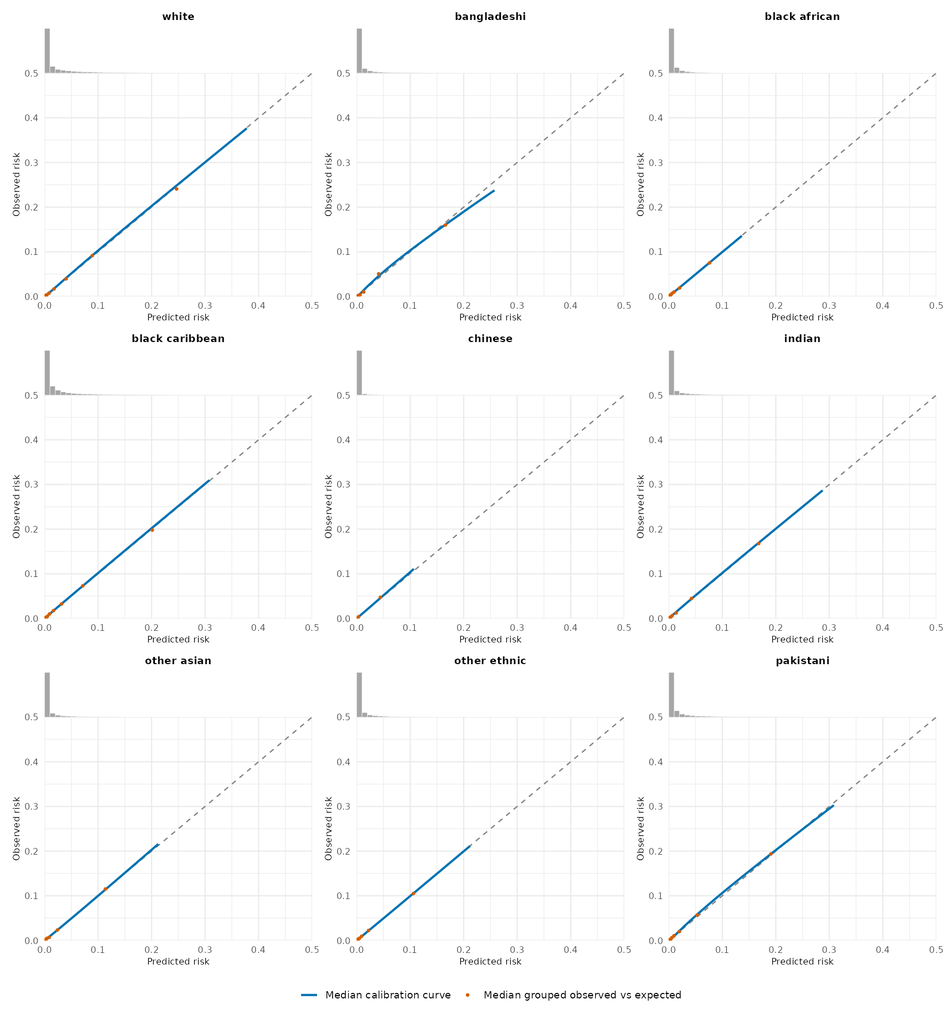

**Figure S9. Internal-validation calibration by ethnicity, male model.**

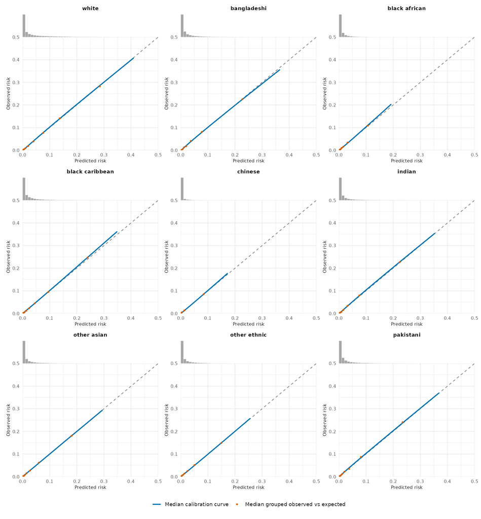

**Figure S10. Internal-validation calibration by age category, female model.**

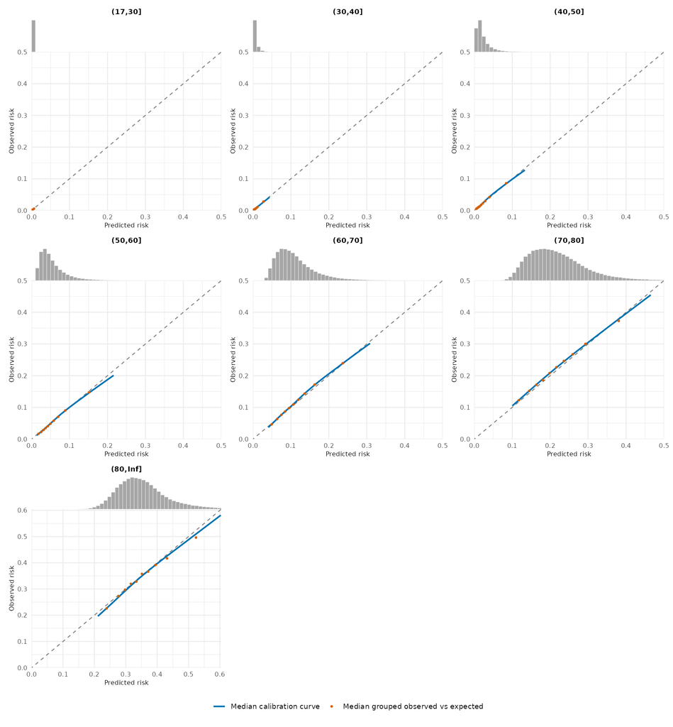

**Figure S11. Internal-validation calibration by age category, male model.**

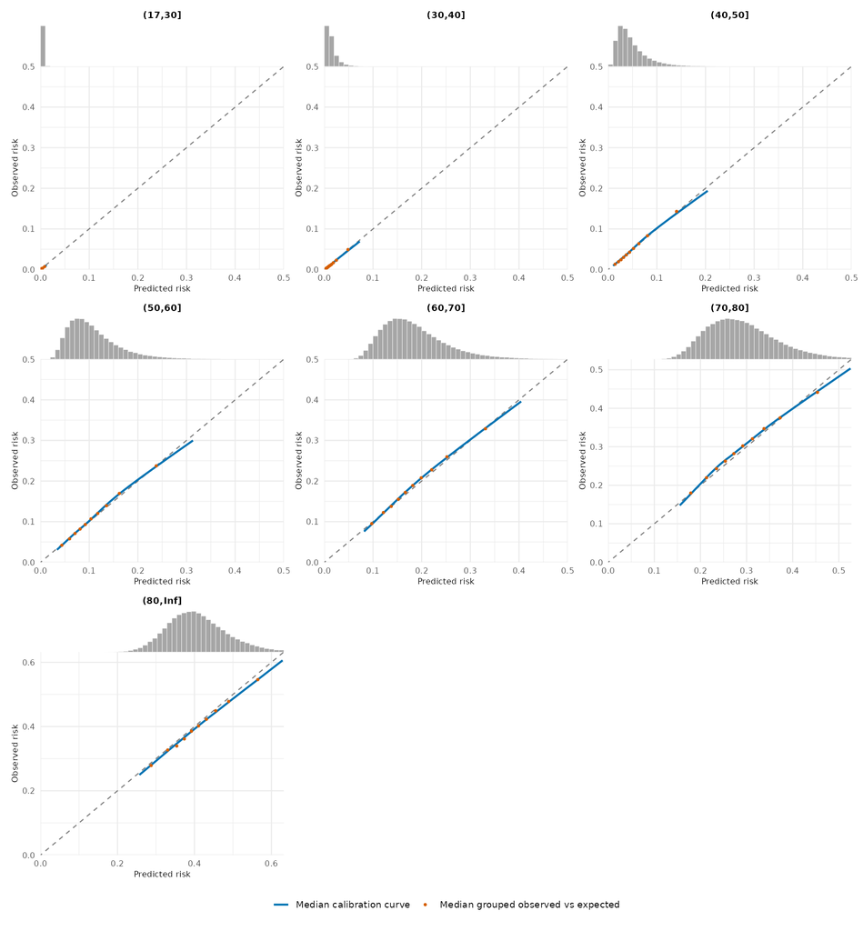

**Figure S12. Internal-validation calibration by region, female model.**

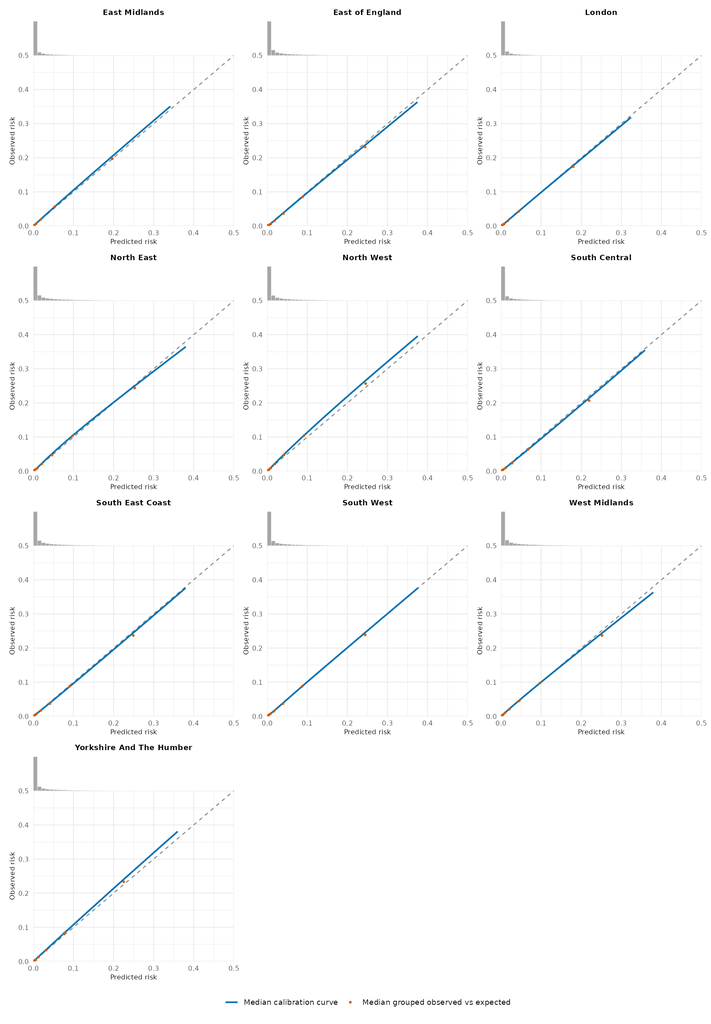

**Figure S13. Internal-validation calibration by region, male model.**

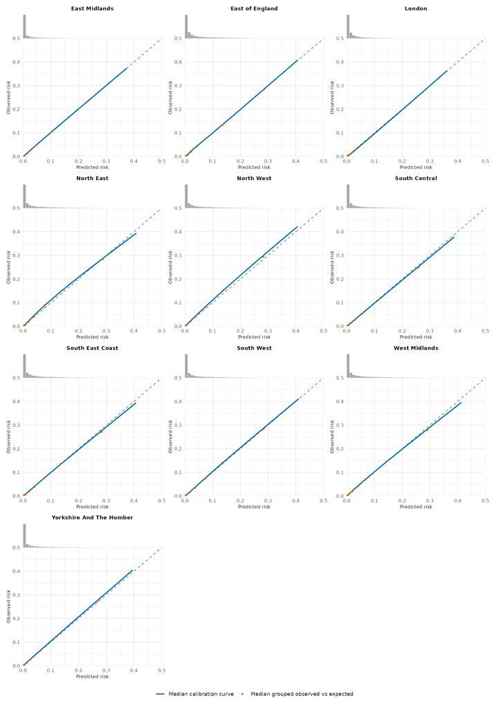

# 4 Instability analysis

## 4.1 Variation of performance metrics across the bootstrap iterations (test performance)

The following tables show the 2.5th, 50th and 97.5th percentiles of test performance across the bootstrap iterations. These percentiles describe variation in performance when models developed in bootstrap samples were evaluated in the corresponding original imputed datasets. They are not confidence intervals for the optimism-adjusted estimates.

Table S8. Distribution of test performance across bootstrap iterations, female model.

| Metric | 2.5th percentile | 50th percentile | 97.5th percentile |
| --- | --- | --- | --- |
| ICI | 0.000 | 0.001 | 0.001 |
| E50 | 0.000 | 0.000 | 0.000 |
| E90 | 0.002 | 0.002 | 0.003 |
| Discrimination | 0.875 | 0.875 | 0.875 |

Table S9. Distribution of test performance across bootstrap iterations, male model.

| Metric | 2.5th percentile | 50th percentile | 97.5th percentile |
| --- | --- | --- | --- |
| ICI | 0.001 | 0.001 | 0.001 |
| E50 | 0.000 | 0.001 | 0.001 |
| E90 | 0.002 | 0.002 | 0.003 |
| Discrimination | 0.859 | 0.859 | 0.859 |

## 4.2 Variation of calibration curves across the bootstrap iterations (test performance)

These curves illustrate variation in calibration when models developed in bootstrap samples were evaluated in the corresponding original imputed datasets.

**Figure S14. Bootstrapped test calibration curves, female and male models.**

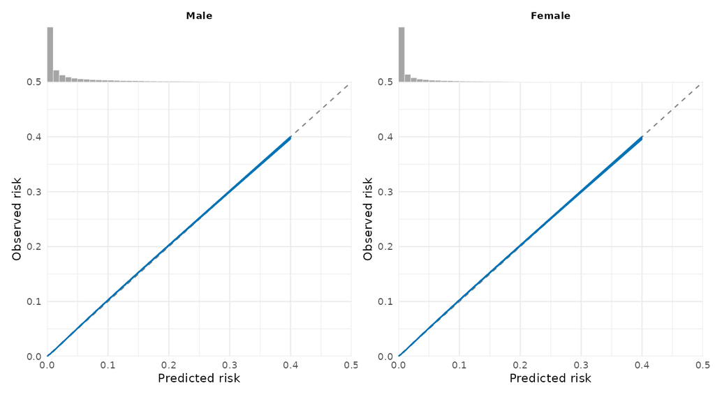

## 4.3 Instability plots for individual risk

These plot illustrate variance in risk on the individual level across the different bootstrapped models. All individual risks are based on synthetic data.

**Figure S15. Individual-risk instability, female model.**

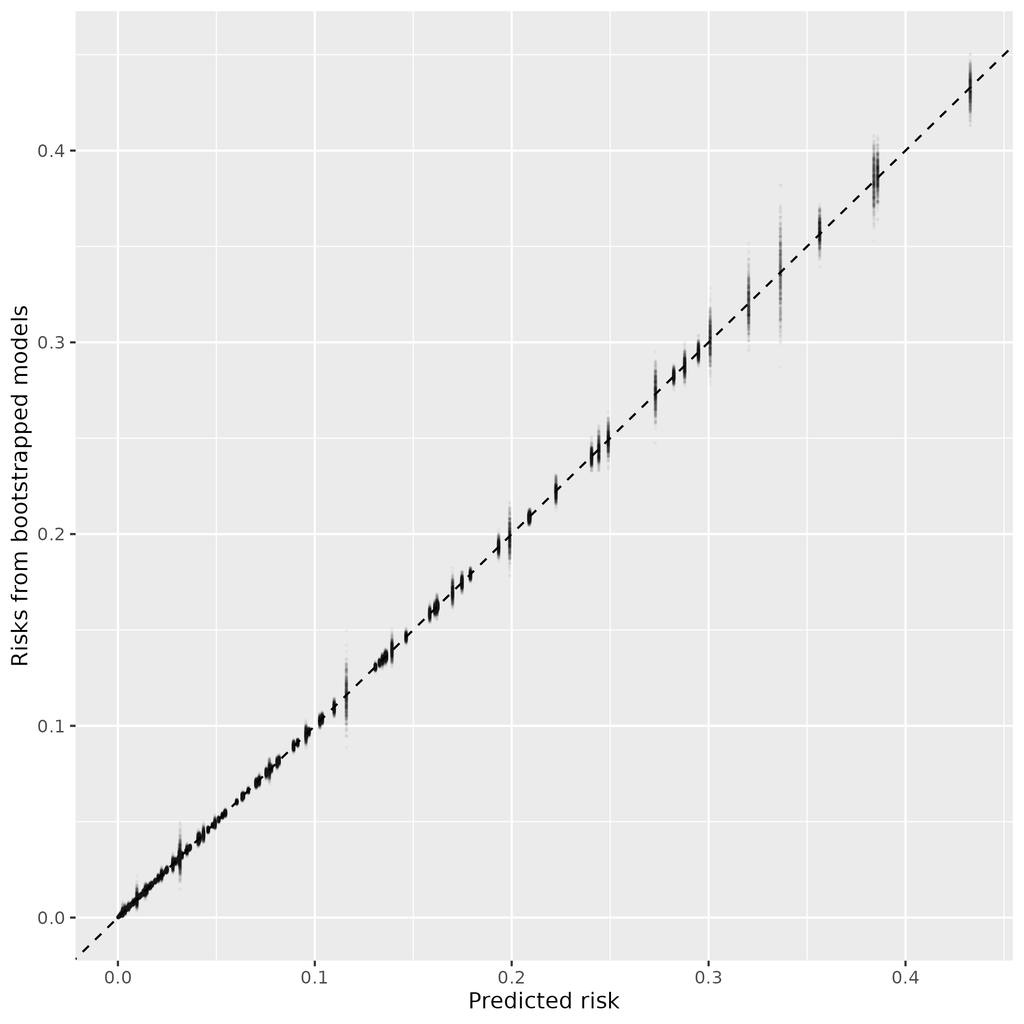

**Figure S16. Individual-risk instability, male model.**

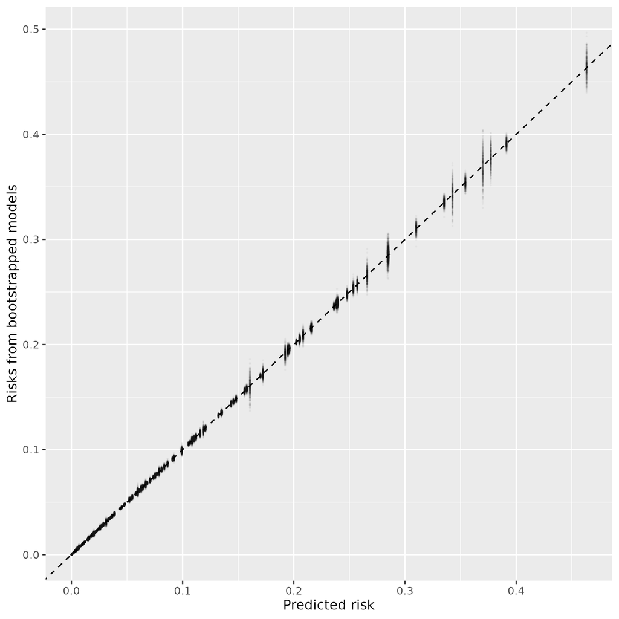

# 5 Temporal validation

## 5.1 Calibration of the initial risk-estimation component (baseline layer)

### 5.1.1 ICI, E50, E90 and discrimination

Performance values are shown to three decimal places; follow-up years are whole numbers. These are not optimism-adjusted estimates.

Table S10. Temporal initial risk-estimation performance, female model.

| Follow-up index (years) | Prediction interval | N | ICI | E50 | E90 | Discrimination |
| --- | --- | --- | --- | --- | --- | --- |
| 1 | 5 | 8,185,110 | 0.001 | 0.000 | 0.001 | 0.867 |
| 2 | 5 | 6,862,564 | 0.001 | 0.000 | 0.003 | 0.859 |
| 3 | 5 | 5,856,477 | 0.002 | 0.001 | 0.005 | 0.853 |
| 4 | 5 | 5,105,684 | 0.002 | 0.001 | 0.006 | 0.847 |
| 5 | 5 | 4,505,468 | 0.003 | 0.001 | 0.007 | 0.841 |
| 1 | 10 | 8,185,110 | 0.001 | 0.000 | 0.002 | 0.867 |
| 2 | 10 | 6,862,564 | 0.003 | 0.001 | 0.007 | 0.859 |
| 3 | 10 | 5,856,477 | 0.004 | 0.001 | 0.010 | 0.853 |
| 4 | 10 | 5,105,684 | 0.004 | 0.002 | 0.012 | 0.847 |
| 5 | 10 | 4,505,468 | 0.005 | 0.002 | 0.013 | 0.841 |

Table S11. Temporal initial risk-estimation performance, male model.

| Follow-up index (years) | Prediction interval | N | ICI | E50 | E90 | Discrimination |
| --- | --- | --- | --- | --- | --- | --- |
| 1 | 5 | 8,085,083 | 0.001 | 0.000 | 0.001 | 0.850 |
| 2 | 5 | 6,924,039 | 0.001 | 0.001 | 0.003 | 0.842 |
| 3 | 5 | 5,976,201 | 0.002 | 0.001 | 0.004 | 0.834 |
| 4 | 5 | 5,205,178 | 0.002 | 0.001 | 0.004 | 0.826 |
| 5 | 5 | 4,577,150 | 0.002 | 0.001 | 0.004 | 0.818 |
| 1 | 10 | 8,085,083 | 0.001 | 0.001 | 0.002 | 0.850 |
| 2 | 10 | 6,924,039 | 0.003 | 0.001 | 0.006 | 0.842 |
| 3 | 10 | 5,976,201 | 0.004 | 0.002 | 0.008 | 0.834 |
| 4 | 10 | 5,205,178 | 0.004 | 0.002 | 0.009 | 0.826 |
| 5 | 10 | 4,577,150 | 0.004 | 0.002 | 0.009 | 0.818 |

### 5.1.2 Calibration plots

Each image is a five-panel grid for follow-up index dates 1 to 5 years after baseline.

**Figure S17. Temporal initial risk-estimation calibration, female model, 5-year prediciton interval.**

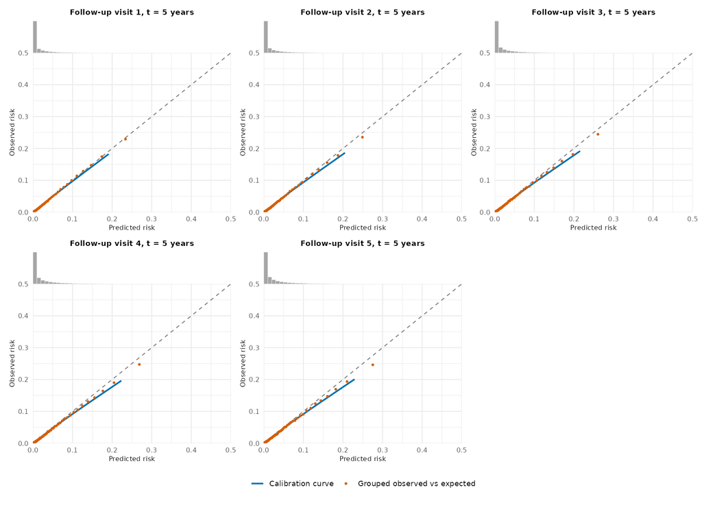

**Figure S18. Temporal initial risk-estimation calibration, male model, 5-year prediciton interval.**

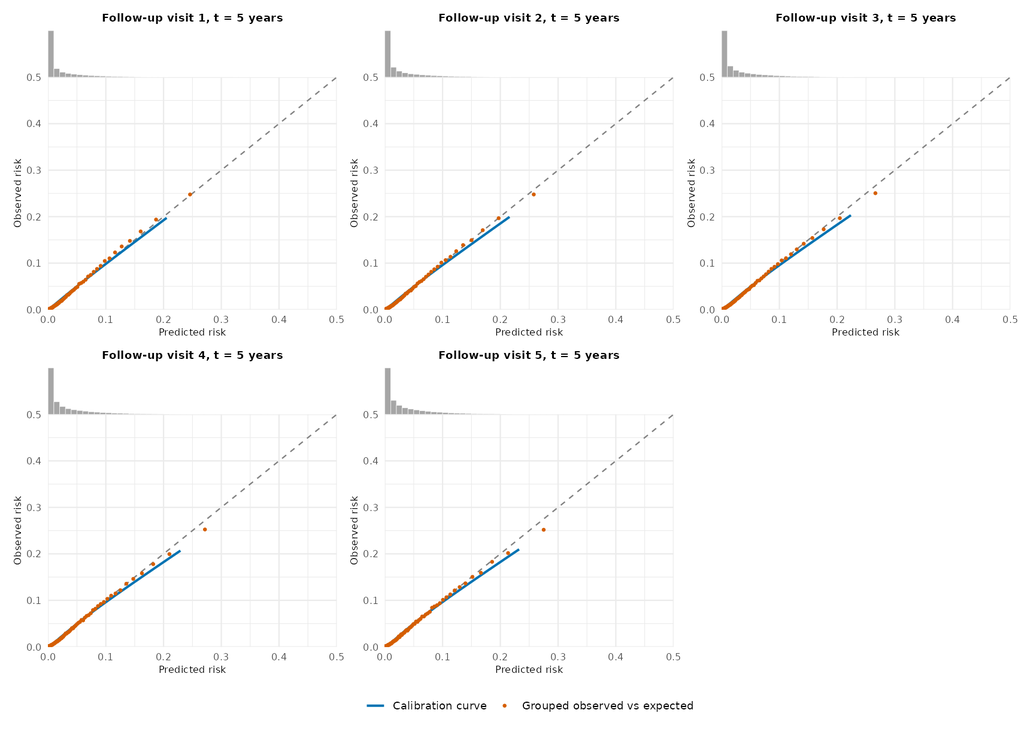

**Figure S19. Temporal initial risk-estimation calibration, female model, 10-year prediciton interval.**

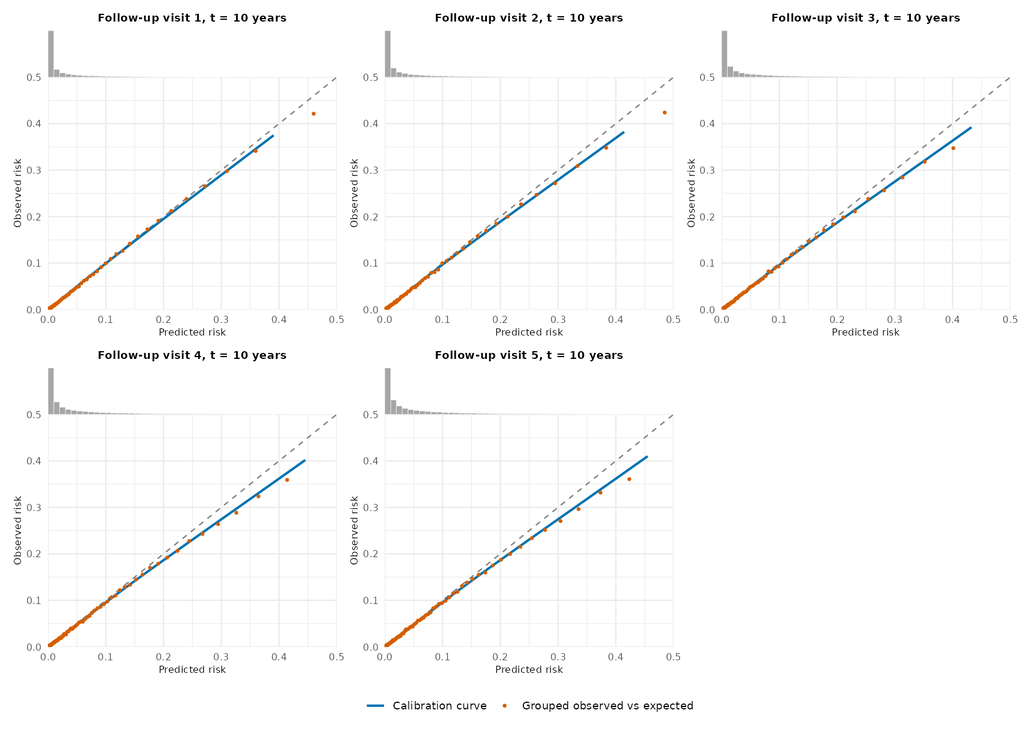

**Figure S20. Temporal initial risk-estimation calibration, male model, 10-year prediciton interval.**

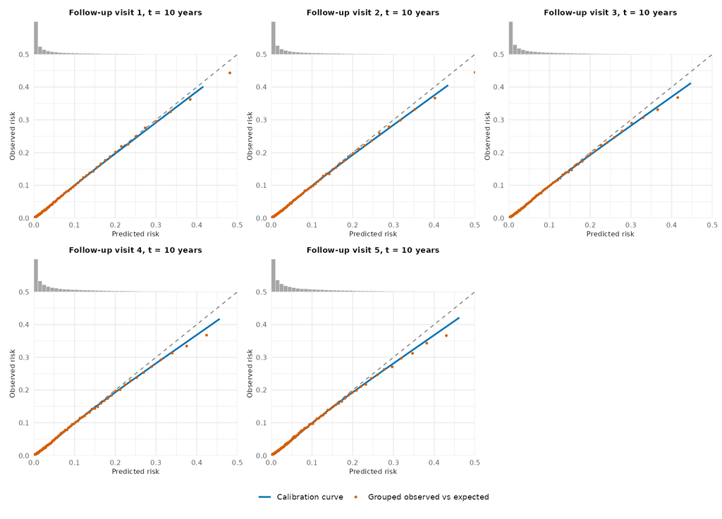

## 5.2 Calibration of the interventional component

### 5.2.1 ICI, E50, E90 and discrimination

The interventional results cover SBP, non-HDL cholesterol, BMI and smoking. Performance values are shown to three decimal places; follow-up years are whole numbers.

Table S12. Temporal interventional performance, female model.

| Risk factor | Follow-up index (years) | Prediction interval | N | ICI | E50 | E90 | Discrimination |
| --- | --- | --- | --- | --- | --- | --- | --- |
| SBP | 1 | 5 | 6,561,130 | 0.002 | 0.000 | 0.005 | 0.858 |
| SBP | 2 | 5 | 5,541,764 | 0.003 | 0.000 | 0.004 | 0.850 |
| SBP | 3 | 5 | 4,757,278 | 0.004 | 0.000 | 0.004 | 0.843 |
| SBP | 4 | 5 | 4,166,914 | 0.004 | 0.000 | 0.004 | 0.837 |
| SBP | 5 | 5 | 3,685,380 | 0.004 | 0.001 | 0.005 | 0.831 |
| Non-HDL cholesterol | 1 | 5 | 1,431,904 | 0.003 | 0.003 | 0.005 | 0.759 |
| Non-HDL cholesterol | 2 | 5 | 1,223,750 | 0.004 | 0.003 | 0.006 | 0.752 |
| Non-HDL cholesterol | 3 | 5 | 1,058,597 | 0.004 | 0.003 | 0.007 | 0.747 |
| Non-HDL cholesterol | 4 | 5 | 924,823 | 0.004 | 0.002 | 0.007 | 0.743 |
| Non-HDL cholesterol | 5 | 5 | 806,480 | 0.004 | 0.002 | 0.007 | 0.738 |
| BMI | 1 | 5 | 5,146,566 | 0.001 | 0.000 | 0.001 | 0.869 |
| BMI | 2 | 5 | 4,231,071 | 0.001 | 0.000 | 0.003 | 0.861 |
| BMI | 3 | 5 | 3,537,767 | 0.002 | 0.000 | 0.004 | 0.855 |
| BMI | 4 | 5 | 3,029,879 | 0.002 | 0.001 | 0.006 | 0.849 |
| BMI | 5 | 5 | 2,627,558 | 0.002 | 0.001 | 0.007 | 0.843 |
| Smoking | 1 | 5 | 7,519,323 | 0.001 | 0.000 | 0.001 | 0.865 |
| Smoking | 2 | 5 | 6,305,907 | 0.001 | 0.000 | 0.003 | 0.857 |
| Smoking | 3 | 5 | 5,379,004 | 0.002 | 0.001 | 0.005 | 0.851 |
| Smoking | 4 | 5 | 4,687,163 | 0.003 | 0.001 | 0.007 | 0.844 |
| Smoking | 5 | 5 | 4,131,184 | 0.003 | 0.001 | 0.008 | 0.839 |
| SBP | 1 | 10 | 6,561,130 | 0.005 | 0.001 | 0.009 | 0.858 |
| SBP | 2 | 10 | 5,541,764 | 0.006 | 0.001 | 0.008 | 0.850 |
| SBP | 3 | 10 | 4,757,278 | 0.007 | 0.001 | 0.008 | 0.843 |
| SBP | 4 | 10 | 4,166,914 | 0.007 | 0.001 | 0.009 | 0.837 |
| SBP | 5 | 10 | 3,685,380 | 0.007 | 0.001 | 0.011 | 0.831 |
| Non-HDL cholesterol | 1 | 10 | 1,431,904 | 0.007 | 0.006 | 0.009 | 0.759 |
| Non-HDL cholesterol | 2 | 10 | 1,223,750 | 0.007 | 0.006 | 0.013 | 0.752 |
| Non-HDL cholesterol | 3 | 10 | 1,058,597 | 0.008 | 0.005 | 0.017 | 0.747 |
| Non-HDL cholesterol | 4 | 10 | 924,823 | 0.008 | 0.005 | 0.018 | 0.743 |
| Non-HDL cholesterol | 5 | 10 | 806,480 | 0.008 | 0.004 | 0.018 | 0.738 |
| BMI | 1 | 10 | 5,146,566 | 0.001 | 0.000 | 0.001 | 0.869 |
| BMI | 2 | 10 | 4,231,071 | 0.002 | 0.000 | 0.006 | 0.861 |
| BMI | 3 | 10 | 3,537,767 | 0.003 | 0.001 | 0.009 | 0.855 |
| BMI | 4 | 10 | 3,029,879 | 0.004 | 0.001 | 0.012 | 0.849 |
| BMI | 5 | 10 | 2,627,558 | 0.004 | 0.002 | 0.013 | 0.843 |
| Smoking | 1 | 10 | 7,519,323 | 0.001 | 0.000 | 0.001 | 0.865 |
| Smoking | 2 | 10 | 6,305,907 | 0.003 | 0.001 | 0.007 | 0.857 |
| Smoking | 3 | 10 | 5,379,004 | 0.004 | 0.001 | 0.011 | 0.851 |
| Smoking | 4 | 10 | 4,687,163 | 0.005 | 0.002 | 0.014 | 0.844 |
| Smoking | 5 | 10 | 4,131,184 | 0.006 | 0.002 | 0.015 | 0.839 |

Table S13. Temporal interventional performance, male model.

| Risk factor | Follow-up index (years) | Prediction interval | N | ICI | E50 | E90 | Discrimination |
| --- | --- | --- | --- | --- | --- | --- | --- |
| SBP | 1 | 5 | 4,719,405 | 0.004 | 0.001 | 0.009 | 0.816 |
| SBP | 2 | 5 | 4,049,915 | 0.005 | 0.001 | 0.008 | 0.806 |
| SBP | 3 | 5 | 3,503,516 | 0.005 | 0.001 | 0.008 | 0.797 |
| SBP | 4 | 5 | 3,060,800 | 0.006 | 0.001 | 0.008 | 0.788 |
| SBP | 5 | 5 | 2,692,348 | 0.006 | 0.002 | 0.008 | 0.780 |
| Non-HDL cholesterol | 1 | 5 | 1,382,266 | 0.005 | 0.006 | 0.008 | 0.736 |
| Non-HDL cholesterol | 2 | 5 | 1,178,942 | 0.005 | 0.005 | 0.007 | 0.727 |
| Non-HDL cholesterol | 3 | 5 | 1,014,741 | 0.005 | 0.005 | 0.007 | 0.720 |
| Non-HDL cholesterol | 4 | 5 | 879,099 | 0.005 | 0.005 | 0.007 | 0.713 |
| Non-HDL cholesterol | 5 | 5 | 761,205 | 0.006 | 0.005 | 0.007 | 0.706 |
| BMI | 1 | 5 | 4,198,794 | 0.001 | 0.001 | 0.003 | 0.843 |
| BMI | 2 | 5 | 3,508,285 | 0.001 | 0.001 | 0.002 | 0.833 |
| BMI | 3 | 5 | 2,946,775 | 0.002 | 0.001 | 0.003 | 0.824 |
| BMI | 4 | 5 | 2,501,100 | 0.002 | 0.001 | 0.004 | 0.815 |
| BMI | 5 | 5 | 2,144,906 | 0.002 | 0.001 | 0.004 | 0.807 |
| Smoking | 1 | 5 | 6,735,556 | 0.001 | 0.000 | 0.002 | 0.842 |
| Smoking | 2 | 5 | 5,744,450 | 0.001 | 0.000 | 0.002 | 0.833 |
| Smoking | 3 | 5 | 4,933,295 | 0.002 | 0.001 | 0.004 | 0.824 |
| Smoking | 4 | 5 | 4,274,919 | 0.002 | 0.001 | 0.004 | 0.815 |
| Smoking | 5 | 5 | 3,736,533 | 0.002 | 0.001 | 0.005 | 0.807 |
| SBP | 1 | 10 | 4,719,405 | 0.007 | 0.001 | 0.015 | 0.816 |
| SBP | 2 | 10 | 4,049,915 | 0.009 | 0.001 | 0.015 | 0.806 |
| SBP | 3 | 10 | 3,503,516 | 0.009 | 0.001 | 0.014 | 0.797 |
| SBP | 4 | 10 | 3,060,800 | 0.010 | 0.002 | 0.015 | 0.788 |
| SBP | 5 | 10 | 2,692,348 | 0.011 | 0.003 | 0.018 | 0.780 |
| Non-HDL cholesterol | 1 | 10 | 1,382,266 | 0.009 | 0.009 | 0.013 | 0.736 |
| Non-HDL cholesterol | 2 | 10 | 1,178,942 | 0.009 | 0.008 | 0.014 | 0.727 |
| Non-HDL cholesterol | 3 | 10 | 1,014,741 | 0.010 | 0.008 | 0.018 | 0.720 |
| Non-HDL cholesterol | 4 | 10 | 879,099 | 0.010 | 0.009 | 0.021 | 0.713 |
| Non-HDL cholesterol | 5 | 10 | 761,205 | 0.010 | 0.008 | 0.021 | 0.706 |
| BMI | 1 | 10 | 4,198,794 | 0.002 | 0.001 | 0.004 | 0.843 |
| BMI | 2 | 10 | 3,508,285 | 0.003 | 0.002 | 0.005 | 0.833 |
| BMI | 3 | 10 | 2,946,775 | 0.004 | 0.002 | 0.008 | 0.824 |
| BMI | 4 | 10 | 2,501,100 | 0.004 | 0.002 | 0.011 | 0.815 |
| BMI | 5 | 10 | 2,144,906 | 0.005 | 0.002 | 0.012 | 0.807 |
| Smoking | 1 | 10 | 6,735,556 | 0.001 | 0.001 | 0.003 | 0.842 |
| Smoking | 2 | 10 | 5,744,450 | 0.003 | 0.001 | 0.005 | 0.833 |
| Smoking | 3 | 10 | 4,933,295 | 0.003 | 0.001 | 0.008 | 0.824 |
| Smoking | 4 | 10 | 4,274,919 | 0.004 | 0.002 | 0.010 | 0.815 |
| Smoking | 5 | 10 | 3,736,533 | 0.005 | 0.003 | 0.012 | 0.807 |

### 5.2.2 Calibration plots (5-year prediction interval)

Each image is a five-panel grid for follow-up index dates 1 to 5 years after baseline.

**Figure S21. Temporal interventional calibration for SBP, female model, 5-year prediciton interval.**

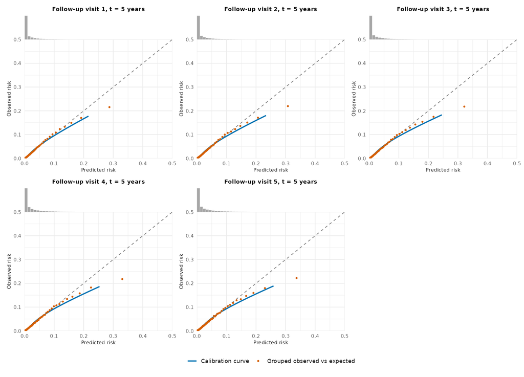

**Figure S22. Temporal interventional calibration for SBP, male model, 5-year prediciton interval.**

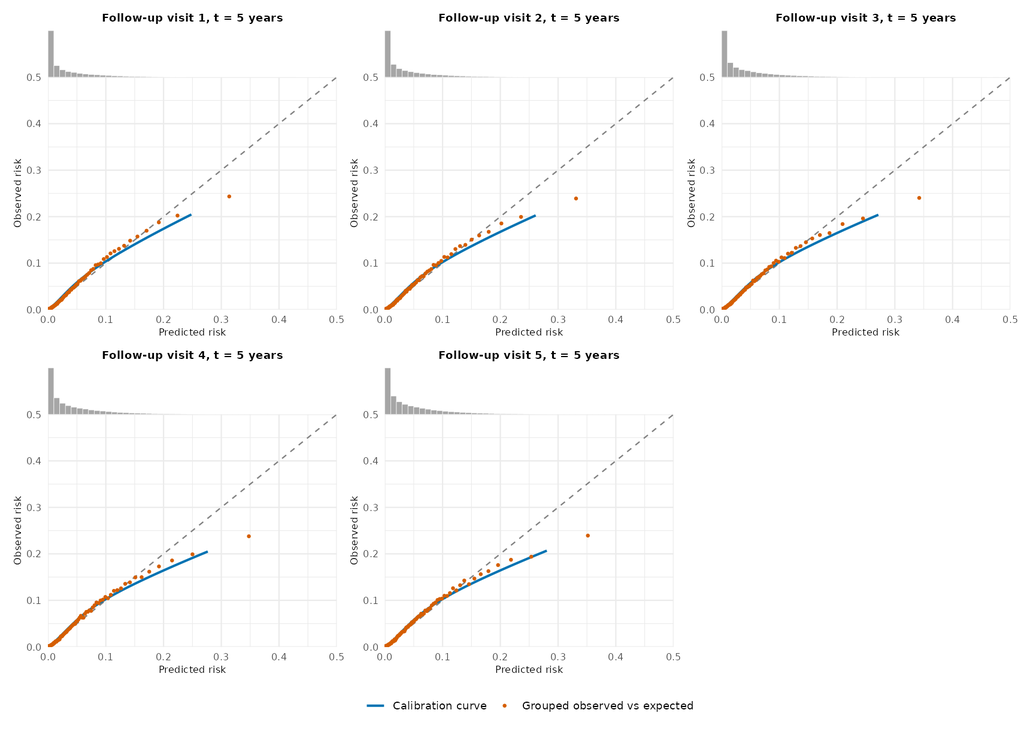

**Figure S23. Temporal interventional calibration for non-HDL cholesterol, female model, 5-year prediciton interval.**

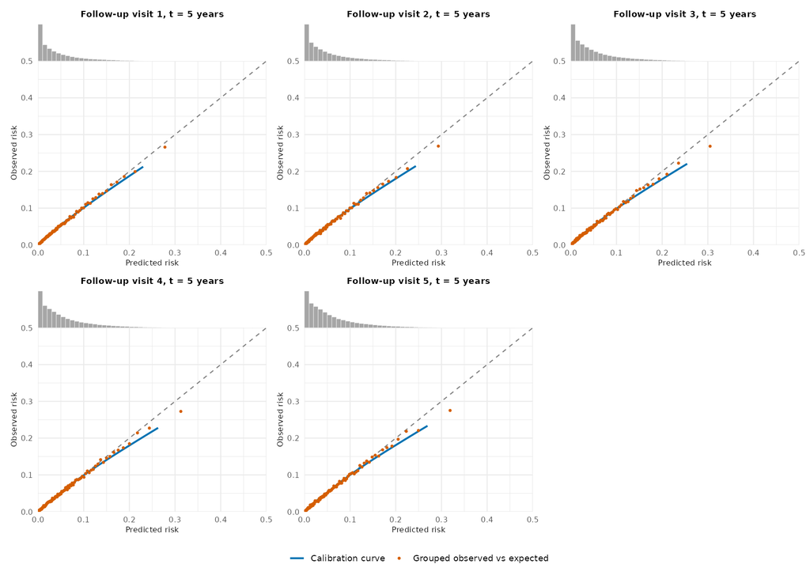

**Figure S24. Temporal interventional calibration for non-HDL cholesterol, male model, 5-year prediciton interval.**

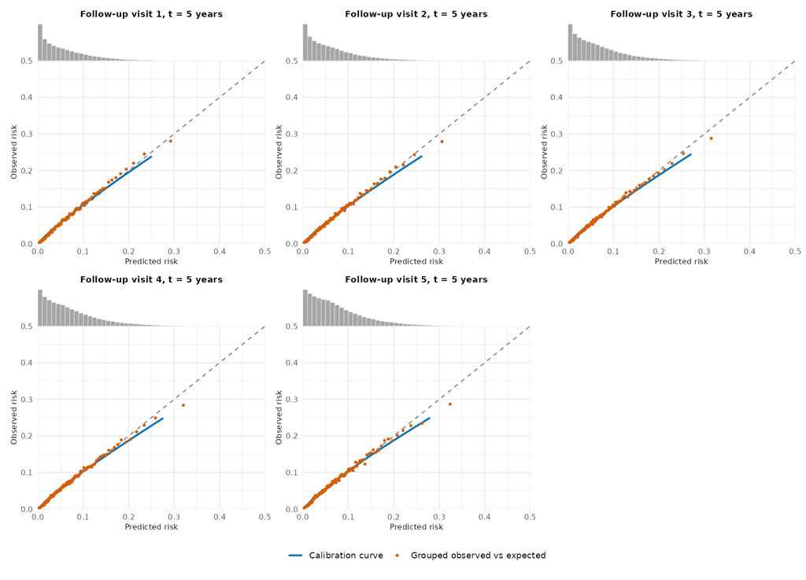

**Figure S25. Temporal interventional calibration for BMI, female model, 5-year prediciton interval.**

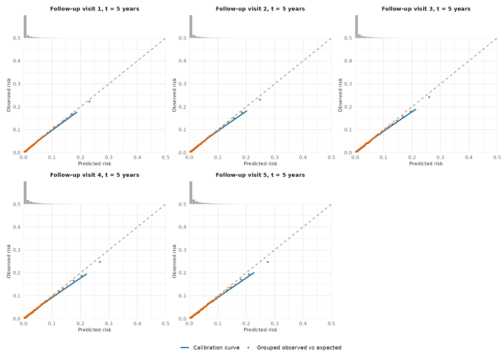

**Figure S26. Temporal interventional calibration for BMI, male model, 5-year prediciton interval.**

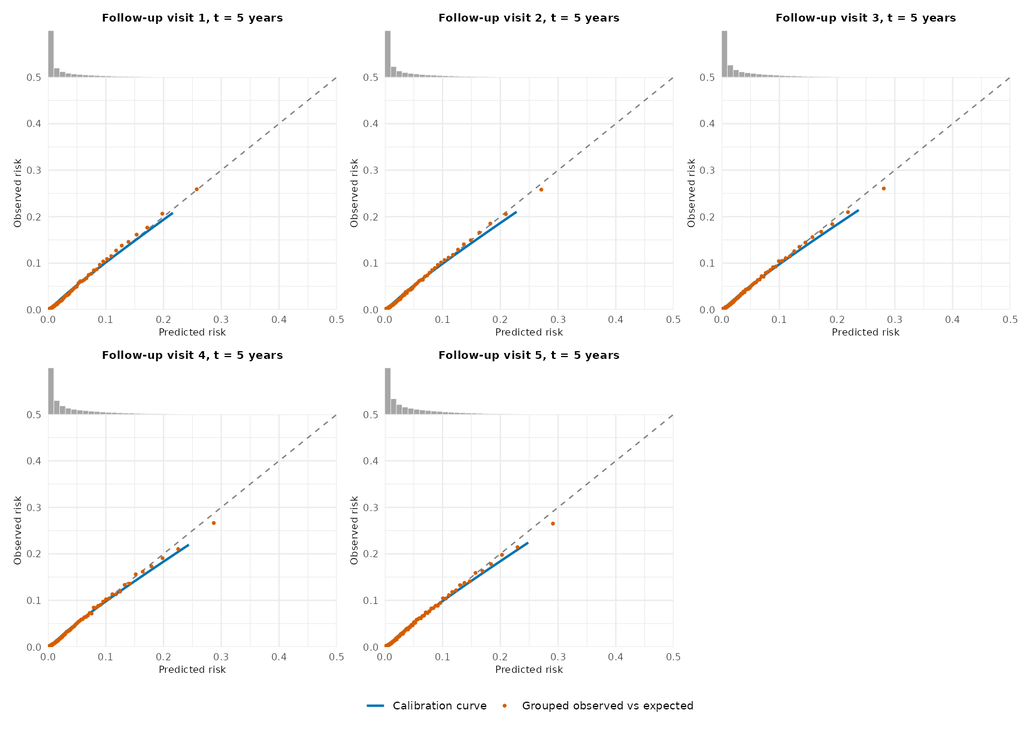

**Figure S27. Temporal interventional calibration for smoking, female model, 5-year prediciton interval.**

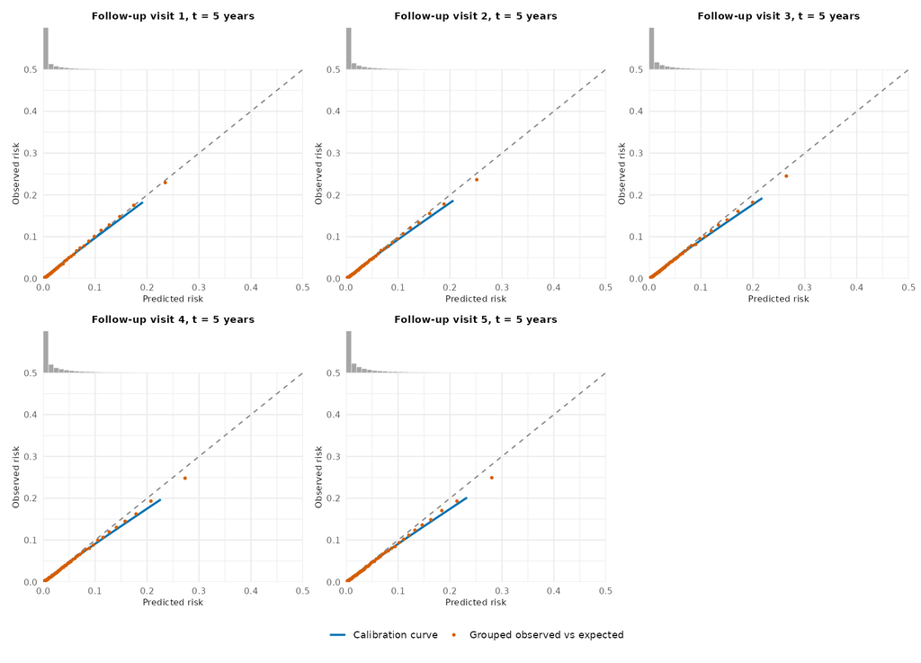

**Figure S28. Temporal interventional calibration for smoking, male model, 5-year prediciton interval.**

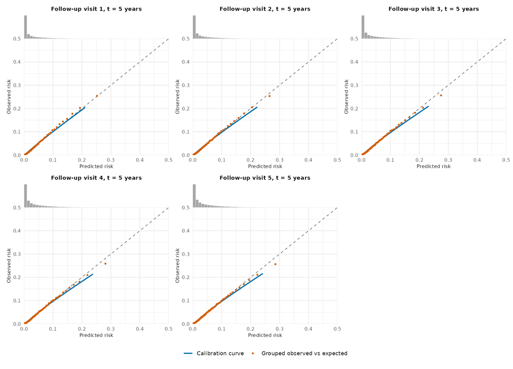

### 5.2.3 Calibration plots (10-year prediction interval)

Each image is a five-panel grid for follow-up index dates 1 to 5 years after baseline.

**Figure S29. Temporal interventional calibration for SBP, female model, 10-year prediciton interval.**

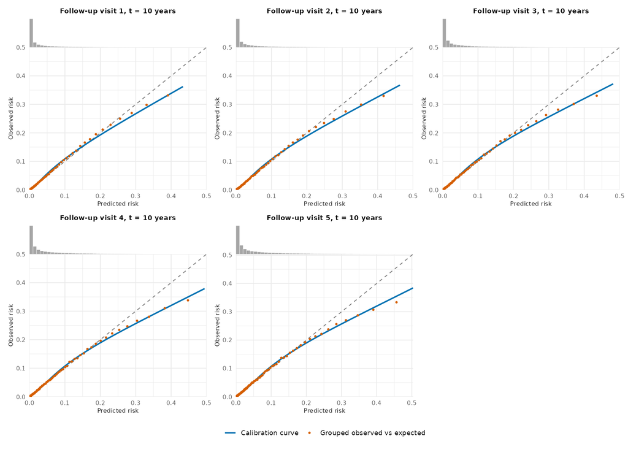

**Figure S30. Temporal interventional calibration for SBP, male model, 10-year prediciton interval.**

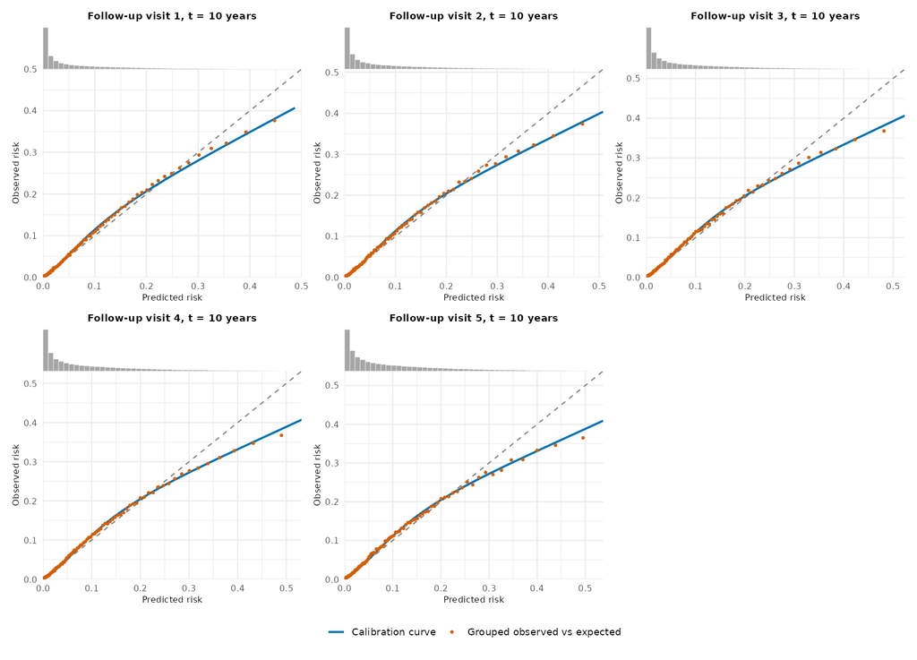

**Figure S31. Temporal interventional calibration for non-HDL cholesterol, female model, 10-year prediciton interval.**

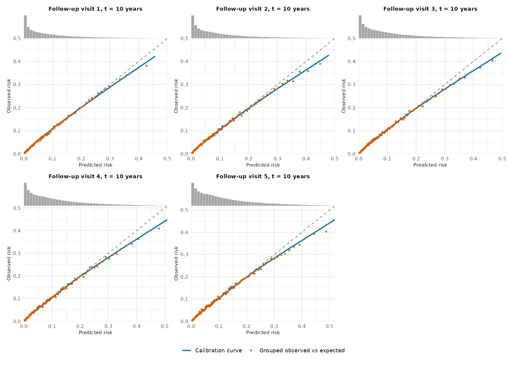

**Figure S32. Temporal interventional calibration for non-HDL cholesterol, male model, 10-year prediciton interval.**

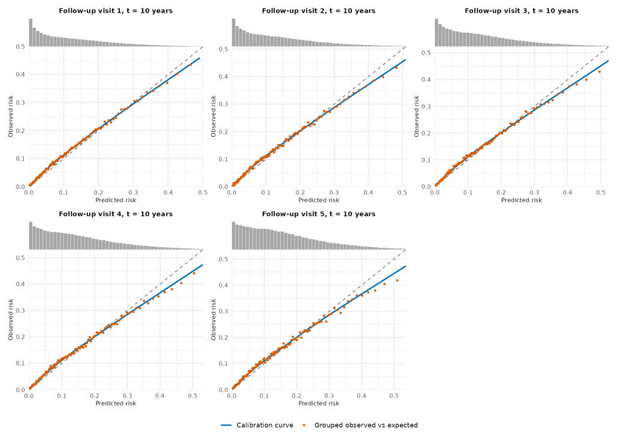

**Figure S33. Temporal interventional calibration for BMI, female model, 10-year prediciton interval.**

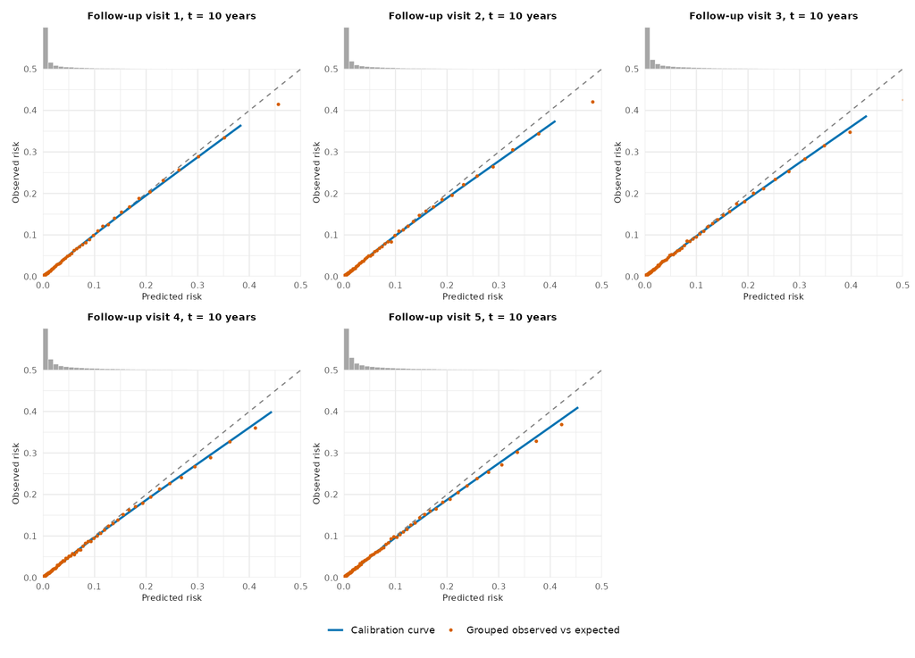

**Figure S34. Temporal interventional calibration for BMI, male model, 10-year prediciton interval.**

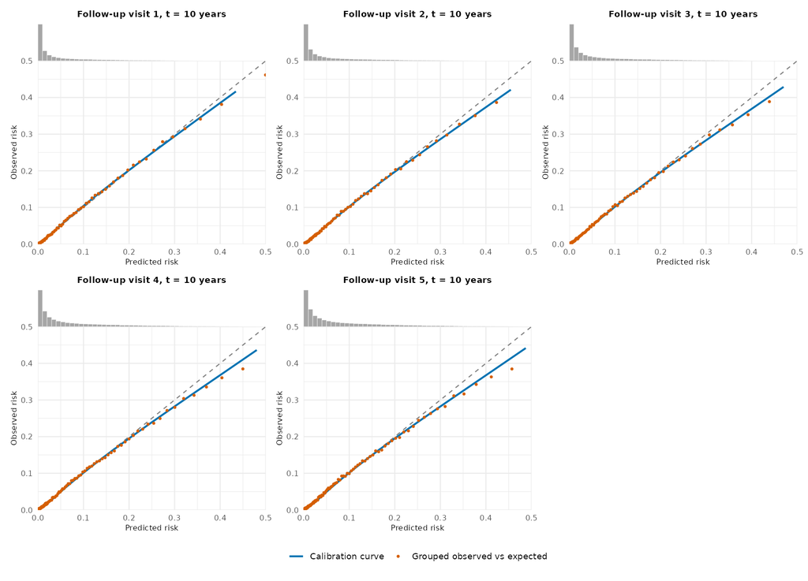

**Figure S35. Temporal interventional calibration for smoking, female model, 10-year prediciton interval.**

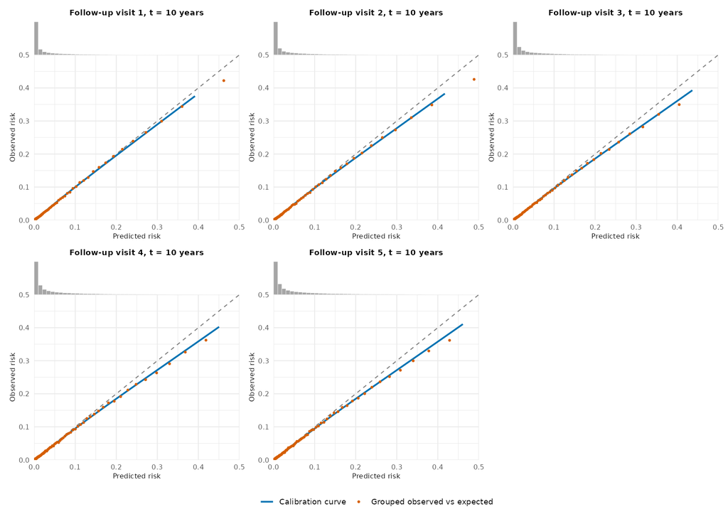

**Figure S36. Temporal interventional calibration for smoking, male model, 10-year prediciton interval.**

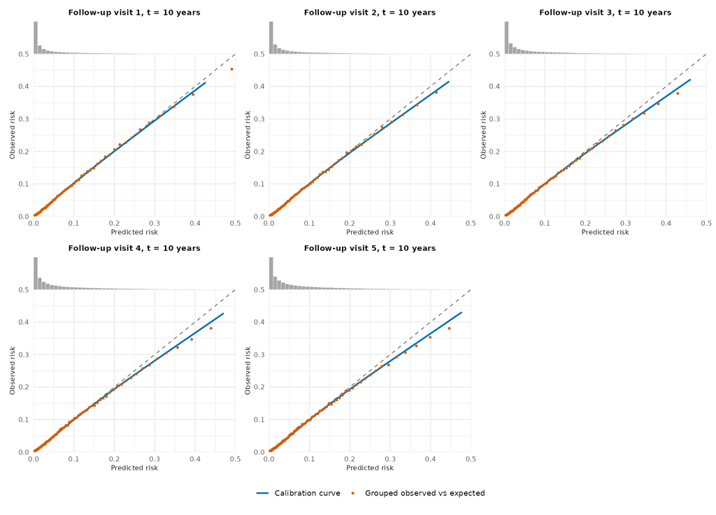